# Penguin Visualization

Module 1

Clemens S. Heithecker

# Setup

In this module we use the tidyverse package to manipulate data frames. We will also use the palmerpenguins package which includes data about penguins.

```r
library(palmerpenguins)
library(tidyverse)
```

*Note*: You can install packages using the `install.packages("palmerpenguins")` command.

# Data

We can now access the data by typing the command `data("penguins")`. In the top- right area of the RStudio screen under the tap “Environment” we can see two data sets.

- *penguins* with 344 observations and 8 variables
- *penguins_raw* with 344 observations and 17 variables

We will only use the first data set (penguins). Take a look at the data set by double clicking on the `penguins` data set in the environment or by using the following commands:

```r
data("penguins")

head(penguins)
```

| species | island | bill_length_mm | bill_depth_mm | flipper_length_mm | body_mass_g | sex | year |
| --- | --- | --- | --- | --- | --- | --- | --- |
| Adelie | Torgersen | 39.1 | 18.7 | 181 | 3750 | male | 2007 |
| Adelie | Torgersen | 39.5 | 17.4 | 186 | 3800 | female | 2007 |
| Adelie | Torgersen | 40.3 | 18.0 | 195 | 3250 | female | 2007 |
| Adelie | Torgersen | NA | NA | NA | NA | NA | 2007 |
| Adelie | Torgersen | 36.7 | 19.3 | 193 | 3450 | female | 2007 |
| Adelie | Torgersen | 39.3 | 20.6 | 190 | 3650 | male | 2007 |

```r
tail(penguins)
```

| species | island | bill_length_mm | bill_depth_mm | flipper_length_mm | body_mass_g | sex | year |
| --- | --- | --- | --- | --- | --- | --- | --- |
| Chinstrap | Dream | 45.7 | 17.0 | 195 | 3650 | female | 2009 |
| Chinstrap | Dream | 55.8 | 19.8 | 207 | 4000 | male | 2009 |
| Chinstrap | Dream | 43.5 | 18.1 | 202 | 3400 | female | 2009 |
| Chinstrap | Dream | 49.6 | 18.2 | 193 | 3775 | male | 2009 |
| Chinstrap | Dream | 50.8 | 19.0 | 210 | 4100 | male | 2009 |
| Chinstrap | Dream | 50.2 | 18.7 | 198 | 3775 | female | 2009 |

```r
summary(penguins)
```

```
##       species          island    bill_length_mm  bill_depth_mm
##  Adelie   :152   Biscoe   :168   Min.   :32.10   Min.   :13.10
##  Chinstrap: 68   Dream    :124   1st Qu.:39.23   1st Qu.:15.60
##  Gentoo   :124   Torgersen: 52   Median :44.45   Median :17.30
##                                  Mean   :43.92   Mean   :17.15
##                                  3rd Qu.:48.50   3rd Qu.:18.70
##                                  Max.   :59.60   Max.   :21.50
##                                  NA's   :2       NA's   :2
##  flipper_length_mm  body_mass_g       sex           year
##  Min.   :172.0     Min.   :2700   female:165   Min.   :2007
##  1st Qu.:190.0     1st Qu.:3550   male  :168   1st Qu.:2007
##  Median :197.0     Median :4050   NA's  : 11   Median :2008
##  Mean   :200.9     Mean   :4202                Mean   :2008
##  3rd Qu.:213.0     3rd Qu.:4750                3rd Qu.:2009
##  Max.   :231.0     Max.   :6300                Max.   :2009
##  NA's   :2         NA's   :2
```

The data set contains 8 variables and 344 individual penguins. If you want to know what all variables mean you can use the command `?penguins` to inspect the documentation.

```r
?penguins
```

```
## starting httpd help server ... done
```

There are some `NA` or missing values in the data set. We can remove those observations using the following code:

```r
penguins <- penguins %>%
  na.omit()
```

Now the number of observations decreased to 333 meaning we lost 11 penguins.

# Plotting Data

In 2005 Hadley Wickham created ggplot as part of his PhD. `ggplot` is a part of the tidyverse package and allows you to plot anything you can imagine.

Any plot in ggplot has (at least) the following parts:

- the command `ggplot()` which tells R to plot.
- a `geom_` that tells ggplot which type of graph should be created. Examples are
  - `geom_point()` for a scatter plot
  - `geom_line()` for a line graph
  - `geom_bar()` for a bar plot
  - `geom_histogram()` for a histogram
  - `geom_boxplot()`

We need to specify how to plot the variables in our graph. In ggplot we can link an **aesthetic** of a graph to a column in a data frame. Examples include

- x-coordinate
- y-coordinate
- size and shape of points
- fill color
- line color
- line size
- transparency (alpha value)
- line type

You can specify the aesthetic within the `ggplot()` function call or the `geom_`. It is often easier to use the aesthetics argument within the `geom_` call especially when dealing with multiple `geom_` in one plot.

## Scatter Plot

Suppose we are interested in the correlation between flipper length and bill length. We assume that animals with a larger flipper will also have a larger bill.

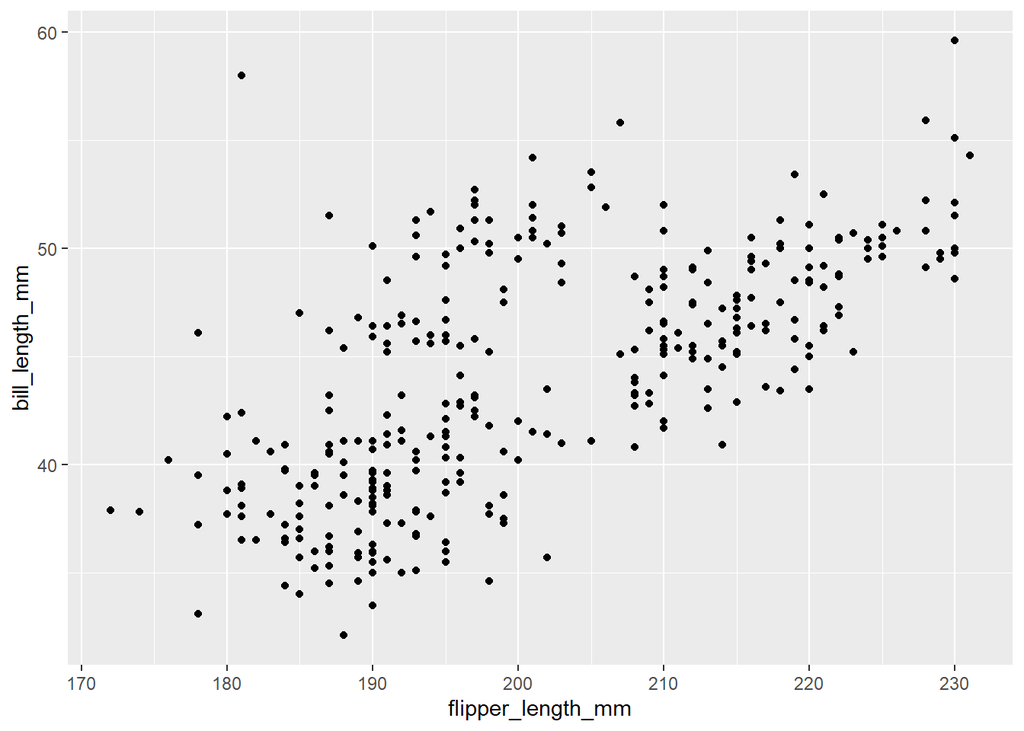

```r
ggplot(data = penguins) +
  geom_point(mapping = aes(x = flipper_length_mm, y = bill_length_mm))
```

## Adding Color to the Plot

We could experiment with adding colors and shapes to this plot. Let’s make the points of the scatter plot red, 3 times bigger and change the shape.

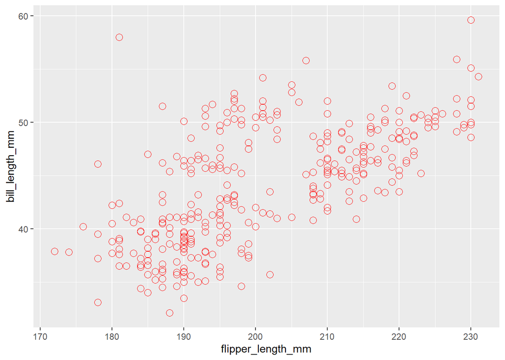

```r
ggplot(data = penguins) +
  geom_point(mapping = aes(x = flipper_length_mm, y = bill_length_mm),
             color = "red", size = 3, shape = 1)
```

Because we added the color, size and shape attributes outside the `aes()` function we apply the same attributes to all data points.

## Adding Dimensions of Species and Sex

It seems that there is a positive correlation between flipper and bill length. Let’s examine if there are group differences between sex and species. In our next plot we will add an aesthetic `color` for species and `shape` for sex to our plot. We should do this inside the `aes()` function because we now want to make the color and the shape dependent on the variables `species` and `sex`.

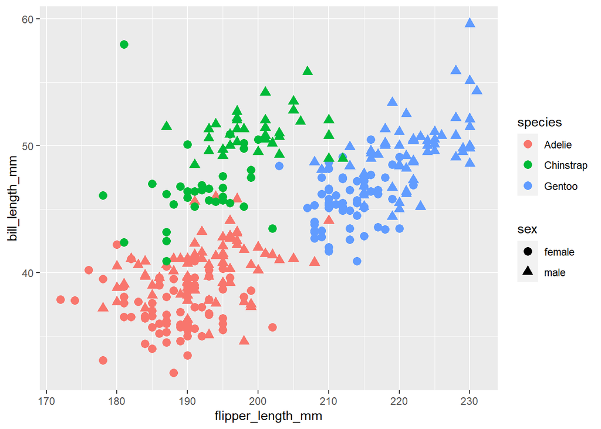

```r
ggplot(data = penguins,
       mapping = aes(x = flipper_length_mm, y = bill_length_mm)) +
  geom_point(mapping = aes(color = species, shape = sex),
             size = 3)
```

## Improving the Plot

We can make the plot nicer by adding labels with `labs()`. We can add

- a title
- a subtitle
- an x-axis label
- a y-axis label
- a caption

We can also add a theme. Check out some examples at https://ggplot2.tidyverse.org/reference/ggtheme.html.

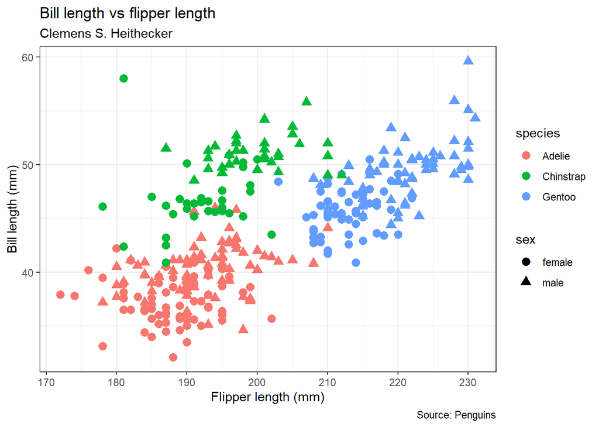

```r
ggplot(data = penguins,
       mapping = aes(x = flipper_length_mm, y = bill_length_mm)) +
  geom_point(size = 3,
             mapping = aes(color = species, shape = sex)) +
  labs(
    title = "Bill length vs flipper length",
    subtitle = "Clemens S. Heithecker",
    x = "Flipper length (mm)",
    y = "Bill length (mm)",
    caption = "Source: Penguins"
  ) +
  theme_bw()
```

# Box Plots

Let’s make a box plot.

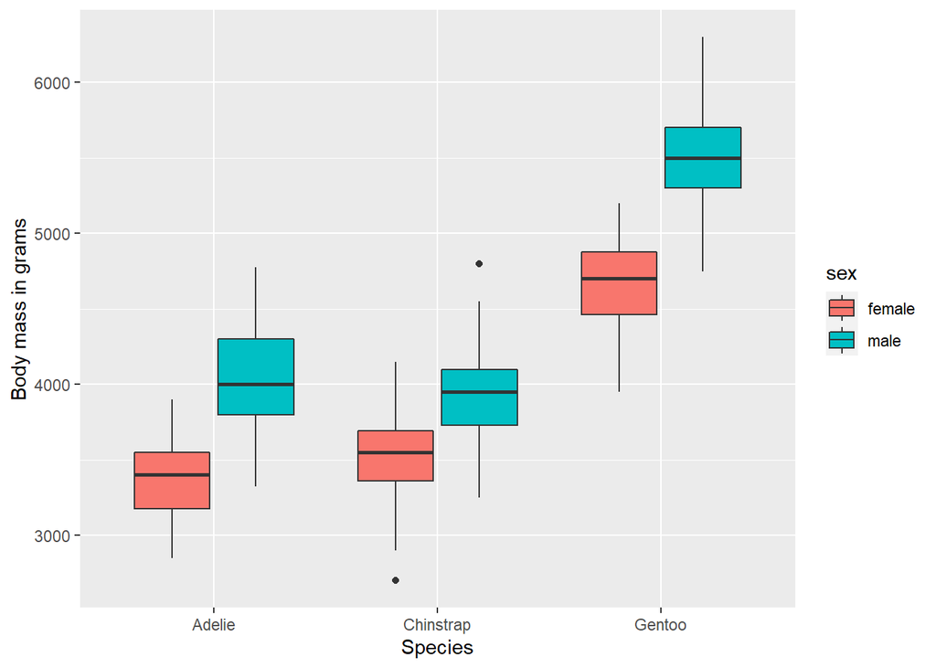

```r
ggplot(data = penguins, mapping = aes(x = species, y = body_mass_g)) +
  geom_boxplot(mapping = aes(fill = sex)) +
  labs(
    x = "Species",
    y = "Body mass in grams"
  )
```

We could also add another dimension by making a plot per island. With this plot we are able to see which species lives on which island and whether species living on different islands have different body masses. We can split the plots per island by using the `facet_wrap(~ island)`.

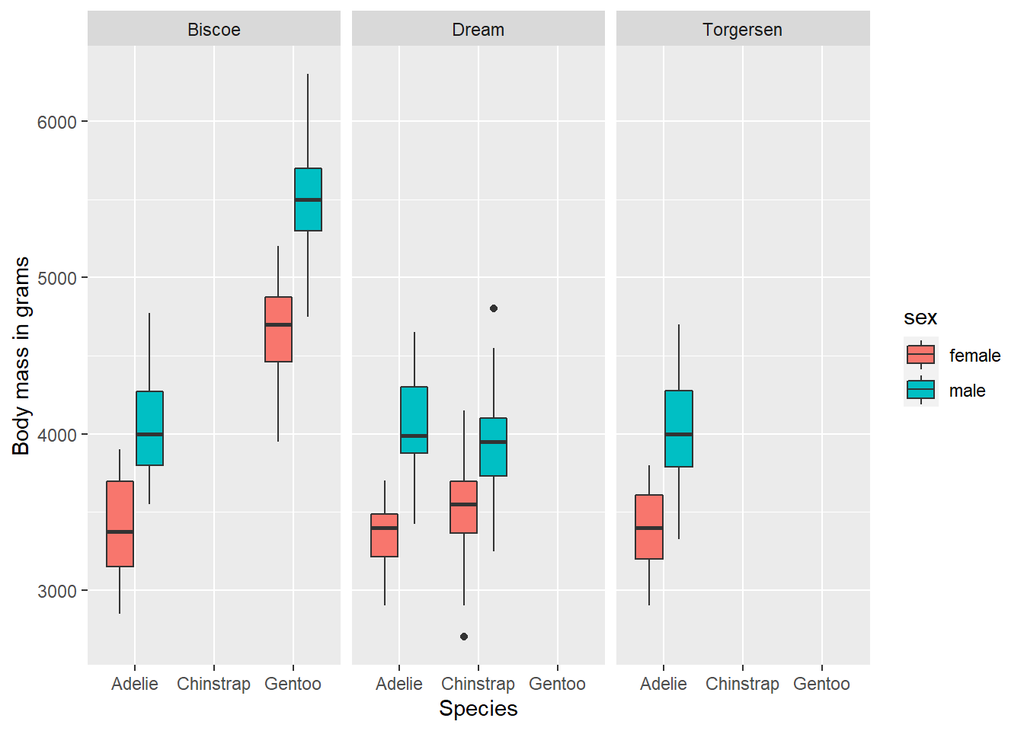

```r
ggplot(data = penguins, mapping = aes(x = species, y = body_mass_g)) +
  geom_boxplot(mapping = aes(fill = sex)) +
  facet_wrap(~ island) +
  labs(
    x = "Species",
    y = "Body mass in grams"
  )
```

Let’s change the colors of the `sex` variable.

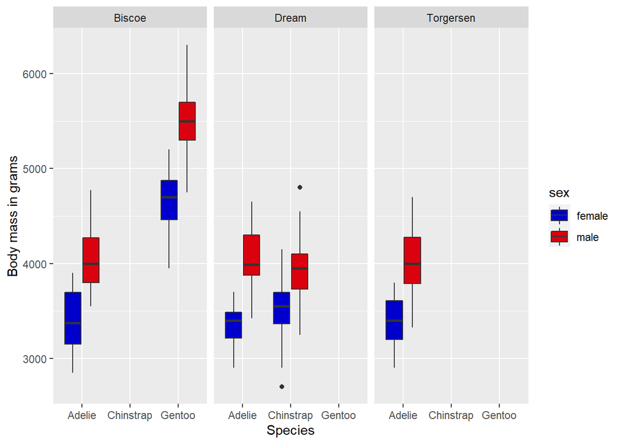

```r
ggplot(data = penguins, mapping = aes(x = species, y = body_mass_g)) +
  geom_boxplot(mapping = aes(fill = sex)) +
  facet_wrap(~ island) +
  scale_fill_manual(values = c("mediumblue", "#DA020E")) +
  labs(
    x = "Species",
    y = "Body mass in grams"
  )
```